# Predicting Weight Lifting Quality

Wesley J. Silva

28 de abril de 2019

# Introduction

In this exercise, the strategy is to predict the weight lifting quality using the original features, ignoring summarized measures at the end of a time window.

For predicting the classes, generalized boosting models (gbm) and random forest approaches were performed. The method with higher accuracy measured was the one selected to make the predictions in the test data.

# Data partition

In order to evaluate the models, considering the validation (“test”) data doesn’t have the “class” varible, the ‘training’ data were splited in a training and data sets.

```r
#### test X training ----
set.seed(342)
inTrain <- createDataPartition(pml_data_transf$classe,p = 0.7, list = F)
training <- pml_data_transf[inTrain,]
testing <- pml_data_transf[-inTrain,]
```

# Feature selection

For reducing dimensionality, it was selected only the variables with relevant differences between groups. Therefore, an ANOVA was performed for each feature available in the dataset.

```r
anova_tests <-
  lapply(select(training,-one_of(window_id)),
         function(x){
           anova(lm(x ~training$classe))$`Pr(>F)`[1]
         }) %>%
  unlist
selected_features <-
  names(anova_tests[anova_tests < 0.05])
```

# Descriptive analysis

The graphs below show some patterns observed for an arbitrary set of variables.

The x-dimension for arm acceleration at the end of the window tends to be lower when the weight lifting is performed the right way.

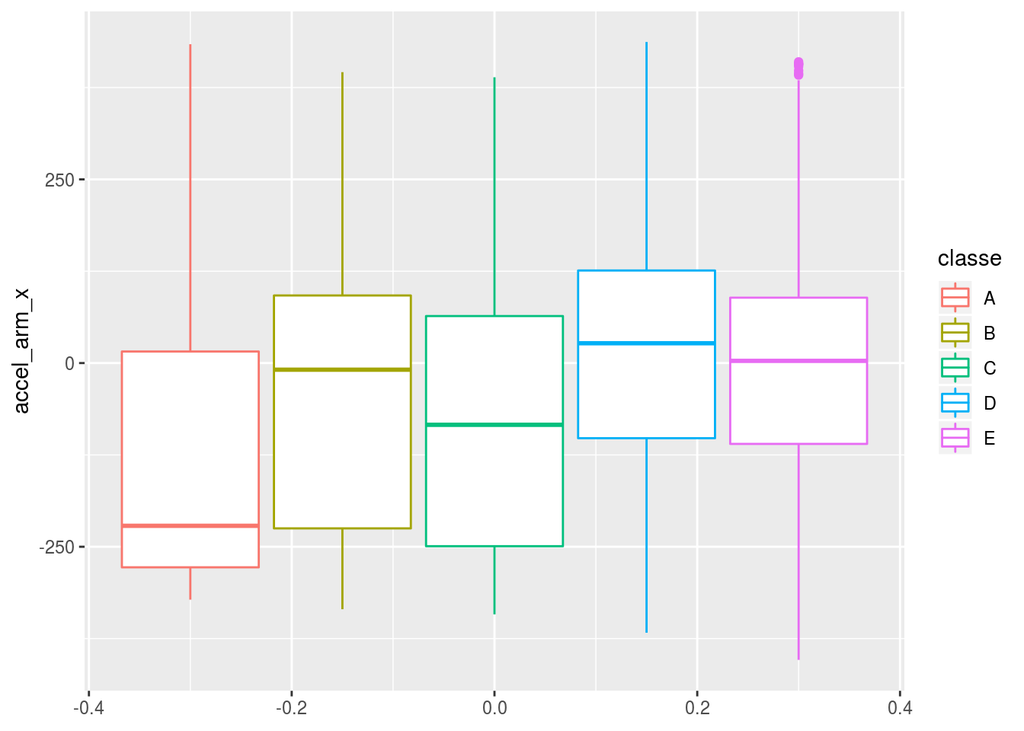

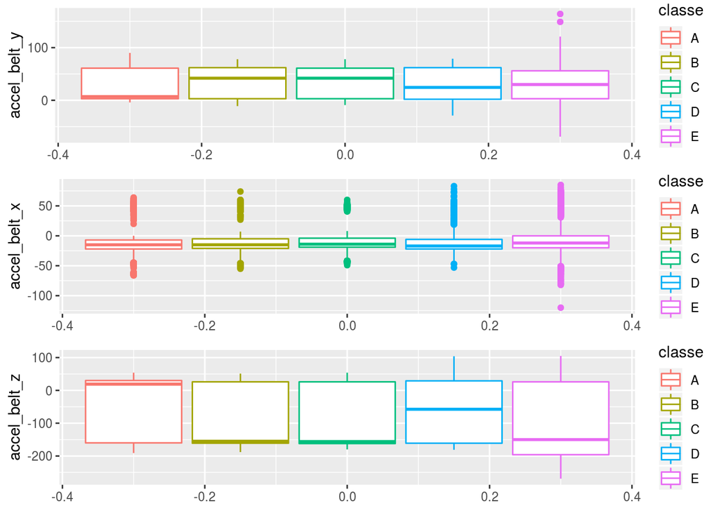

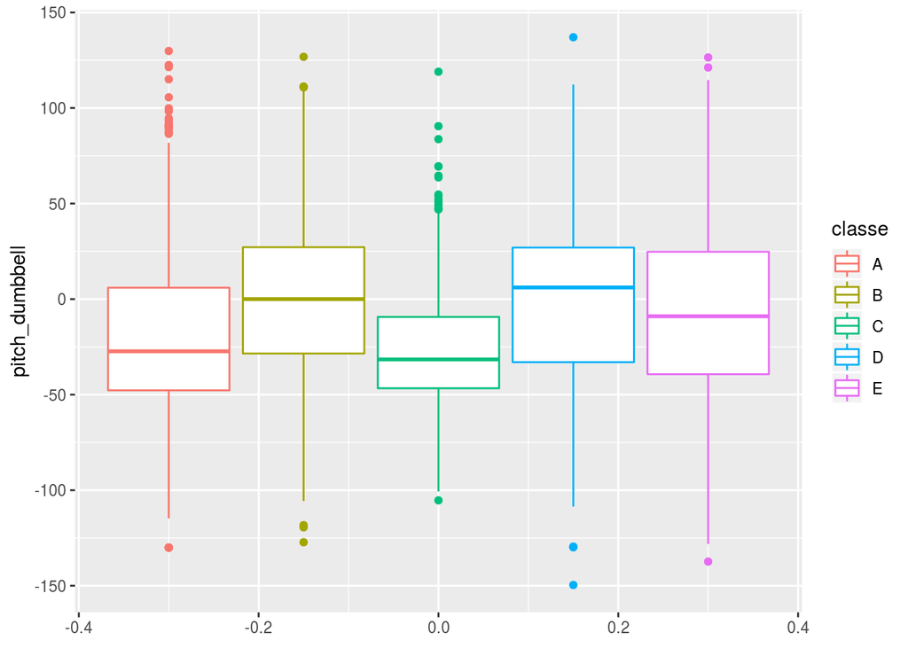

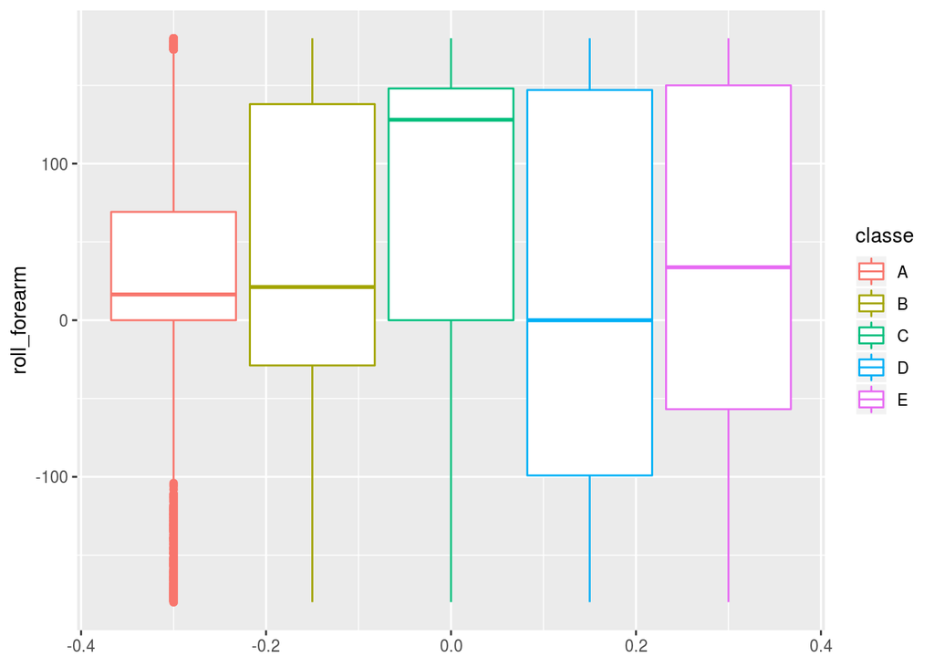

# Training the models

The predictors were trained using “gbm” and “rf” methods for boosting and random forest, respectively.

```r
ti <- Sys.time()
set.seed(3676)
mod_boost <- train(classe~.,method = "gbm",
                   data = select(training,classe,
                                 one_of(selected_features)))
tf2 <- difftime(Sys.time(),ti)

save(mod_boost,file = "fitted_boost.rda")

ti <- Sys.time()
set.seed(3676)
mod_rf <- train(classe~.,method = "rf",
                   data = select(training,classe,
                                 one_of(selected_features)))
tf3 <- difftime(Sys.time(),ti)

# saving the models
save(mod_boost,mod_rf,file = "fitted_models.rda")

# saving the models
save(mod_boost,mod_rf,file = "fitted_models.rda")
```

# Evaluating on the separate test set

Using *boosting* algorithm, the estimated accuracy was 96.2%. On the other hand, random forest showed an accuracy of 99.4%, so random forest is the model used for for predicting the classes.

|  | A | B | C | D | E |
| --- | --- | --- | --- | --- | --- |
| A | 98.51 | 1.0 | 0.42 | 0.06 | 0.000 |
| B | 2.63 | 93.7 | 3.16 | 0.44 | 0.088 |
| C | 0.00 | 3.1 | 95.81 | 1.07 | 0.000 |
| D | 0.21 | 0.1 | 3.84 | 95.54 | 0.311 |
| E | 0.18 | 1.5 | 0.92 | 0.92 | 96.488 |

|  | A | B | C | D | E |
| --- | --- | --- | --- | --- | --- |
| A | 99.76 | 0.000 | 0.000 | 0.00 | 0.000 |
| B | 0.24 | 99.040 | 0.000 | 0.00 | 0.000 |
| C | 0.00 | 0.873 | 98.259 | 0.00 | 0.000 |
| D | 0.00 | 0.000 | 1.644 | 99.89 | 0.093 |
| E | 0.00 | 0.087 | 0.097 | 0.11 | 99.907 |